# Risk Factor Analysis

## Outcome Variable

**Outcome Variable:** haz

## Predictor Variables

**Intervention Variable:** mbmi

**Adjustment Set:**

- arm
- W_mage
- W_fage
- meducyrs
- feducyrs
- single
- brthmon
- delta_W_mage
- delta_W_fage
- delta_meducyrs
- delta_feducyrs
- delta_single
- delta_brthmon

## Stratifying Variables

The analysis was stratified on these variable(s):

- agecat
- studyid
- country

## Data Summary

| agecat | studyid | country | mbmi | n_cell | n |
| --- | --- | --- | --- | --- | --- |
| Birth | ki0047075b-MAL-ED | BANGLADESH | Normal weight | 216 | 246 |
| Birth | ki0047075b-MAL-ED | BANGLADESH | Underweight | 30 | 246 |
| Birth | ki0047075b-MAL-ED | BRAZIL | Normal weight | 175 | 184 |
| Birth | ki0047075b-MAL-ED | BRAZIL | Underweight | 9 | 184 |
| Birth | ki0047075b-MAL-ED | INDIA | Normal weight | 159 | 198 |
| Birth | ki0047075b-MAL-ED | INDIA | Underweight | 39 | 198 |
| Birth | ki0047075b-MAL-ED | NEPAL | Normal weight | 172 | 172 |
| Birth | ki0047075b-MAL-ED | NEPAL | Underweight | 0 | 172 |
| Birth | ki0047075b-MAL-ED | PERU | Normal weight | 271 | 276 |
| Birth | ki0047075b-MAL-ED | PERU | Underweight | 5 | 276 |
| Birth | ki0047075b-MAL-ED | SOUTH AFRICA | Normal weight | 223 | 228 |
| Birth | ki0047075b-MAL-ED | SOUTH AFRICA | Underweight | 5 | 228 |
| Birth | ki0047075b-MAL-ED | TANZANIA, UNITED REPUBLIC OF | Normal weight | 114 | 121 |
| Birth | ki0047075b-MAL-ED | TANZANIA, UNITED REPUBLIC OF | Underweight | 7 | 121 |
| Birth | ki1000304b-SAS-CompFeed | INDIA | Normal weight | 91 | 130 |
| Birth | ki1000304b-SAS-CompFeed | INDIA | Underweight | 39 | 130 |
| Birth | ki1017093-NIH-Birth | BANGLADESH | Normal weight | 23 | 28 |
| Birth | ki1017093-NIH-Birth | BANGLADESH | Underweight | 5 | 28 |
| Birth | ki1017093c-NIH-Crypto | BANGLADESH | Normal weight | 21 | 27 |
| Birth | ki1017093c-NIH-Crypto | BANGLADESH | Underweight | 6 | 27 |
| Birth | ki1119695-PROBIT | BELARUS | Normal weight | 13200 | 13723 |
| Birth | ki1119695-PROBIT | BELARUS | Underweight | 523 | 13723 |
| Birth | ki1126311-ZVITAMBO | ZIMBABWE | Normal weight | 9124 | 9634 |
| Birth | ki1126311-ZVITAMBO | ZIMBABWE | Underweight | 510 | 9634 |
| 6 months | ki0047075b-MAL-ED | BANGLADESH | Normal weight | 209 | 241 |
| 6 months | ki0047075b-MAL-ED | BANGLADESH | Underweight | 32 | 241 |
| 6 months | ki0047075b-MAL-ED | BRAZIL | Normal weight | 199 | 208 |
| 6 months | ki0047075b-MAL-ED | BRAZIL | Underweight | 9 | 208 |
| 6 months | ki0047075b-MAL-ED | INDIA | Normal weight | 186 | 235 |
| 6 months | ki0047075b-MAL-ED | INDIA | Underweight | 49 | 235 |

[output cut: 52 more lines]

The following strata were considered:

- agecat: 24 months, studyid: ki0047075b-MAL-ED, country: BANGLADESH
- agecat: 24 months, studyid: ki0047075b-MAL-ED, country: BRAZIL
- agecat: 24 months, studyid: ki0047075b-MAL-ED, country: INDIA
- agecat: 24 months, studyid: ki0047075b-MAL-ED, country: NEPAL
- agecat: 24 months, studyid: ki0047075b-MAL-ED, country: PERU
- agecat: 24 months, studyid: ki0047075b-MAL-ED, country: SOUTH AFRICA
- agecat: 24 months, studyid: ki0047075b-MAL-ED, country: TANZANIA, UNITED REPUBLIC OF
- agecat: 24 months, studyid: ki1017093-NIH-Birth, country: BANGLADESH
- agecat: 24 months, studyid: ki1017093b-PROVIDE, country: BANGLADESH
- agecat: 24 months, studyid: ki1017093c-NIH-Crypto, country: BANGLADESH
- agecat: 24 months, studyid: ki1066203-TanzaniaChild2, country: TANZANIA, UNITED REPUBLIC OF
- agecat: 24 months, studyid: ki1119695-PROBIT, country: BELARUS
- agecat: 24 months, studyid: ki1126311-ZVITAMBO, country: ZIMBABWE
- agecat: 24 months, studyid: ki1148112-LCNI-5, country: MALAWI
- agecat: 6 months, studyid: ki0047075b-MAL-ED, country: BANGLADESH
- agecat: 6 months, studyid: ki0047075b-MAL-ED, country: BRAZIL
- agecat: 6 months, studyid: ki0047075b-MAL-ED, country: INDIA
- agecat: 6 months, studyid: ki0047075b-MAL-ED, country: NEPAL
- agecat: 6 months, studyid: ki0047075b-MAL-ED, country: PERU
- agecat: 6 months, studyid: ki0047075b-MAL-ED, country: SOUTH AFRICA
- agecat: 6 months, studyid: ki0047075b-MAL-ED, country: TANZANIA, UNITED REPUBLIC OF
- agecat: 6 months, studyid: ki1000304b-SAS-CompFeed, country: INDIA
- agecat: 6 months, studyid: ki1017093-NIH-Birth, country: BANGLADESH
- agecat: 6 months, studyid: ki1017093b-PROVIDE, country: BANGLADESH
- agecat: 6 months, studyid: ki1017093c-NIH-Crypto, country: BANGLADESH
- agecat: 6 months, studyid: ki1066203-TanzaniaChild2, country: TANZANIA, UNITED REPUBLIC OF
- agecat: 6 months, studyid: ki1119695-PROBIT, country: BELARUS
- agecat: 6 months, studyid: ki1126311-ZVITAMBO, country: ZIMBABWE
- agecat: 6 months, studyid: ki1148112-LCNI-5, country: MALAWI
- agecat: Birth, studyid: ki0047075b-MAL-ED, country: BANGLADESH
- agecat: Birth, studyid: ki0047075b-MAL-ED, country: BRAZIL
- agecat: Birth, studyid: ki0047075b-MAL-ED, country: INDIA
- agecat: Birth, studyid: ki0047075b-MAL-ED, country: NEPAL
- agecat: Birth, studyid: ki0047075b-MAL-ED, country: PERU
- agecat: Birth, studyid: ki0047075b-MAL-ED, country: SOUTH AFRICA
- agecat: Birth, studyid: ki0047075b-MAL-ED, country: TANZANIA, UNITED REPUBLIC OF
- agecat: Birth, studyid: ki1000304b-SAS-CompFeed, country: INDIA
- agecat: Birth, studyid: ki1017093-NIH-Birth, country: BANGLADESH
- agecat: Birth, studyid: ki1017093c-NIH-Crypto, country: BANGLADESH
- agecat: Birth, studyid: ki1119695-PROBIT, country: BELARUS
- agecat: Birth, studyid: ki1126311-ZVITAMBO, country: ZIMBABWE

### Dropped Strata

Some strata were dropped due to rare outcomes:

- agecat: Birth, studyid: ki0047075b-MAL-ED, country: NEPAL
- agecat: 6 months, studyid: ki0047075b-MAL-ED, country: NEPAL
- agecat: 24 months, studyid: ki0047075b-MAL-ED, country: NEPAL
- agecat: 24 months, studyid: ki0047075b-MAL-ED, country: PERU
- agecat: 24 months, studyid: ki1066203-TanzaniaChild2, country: TANZANIA, UNITED REPUBLIC OF

## Methods Detail

We’re interested in the causal parameters $E[Y_a]$ for all values of $a \in \mathcal{A}$. These parameters represent the mean outcome if, possibly contrary to fact, we intervened to set all units to have $A=a$. Under the randomization and positivity assumptions, these are identified by the statistical parameters $\psi_a=E_W[E_{Y|A,W}(Y|A=a,W)]$. In addition, we’re interested in the mean of $Y$, $E[Y]$ under no intervention (the observed mean). We will estimate these parameters by using SuperLearner to fit the relevant likelihood factors – $E_{Y|A,W}(Y|A=a,W)$ and $p(A=a|W)$, and then updating our likelihood fit using a joint TMLE.

For unadjusted analyses ($W=\{\}$), initial likelihoods were estimated using Lrnr_glm to estimate the simple $E(Y|A)$ and Lrnr_mean to estimate $p(A)$. For adjusted analyses, a small library containing Lrnr_glmnet, Lrnr_xgboost, and Lrnr_mean was used.

# Results Detail

## Results Plots

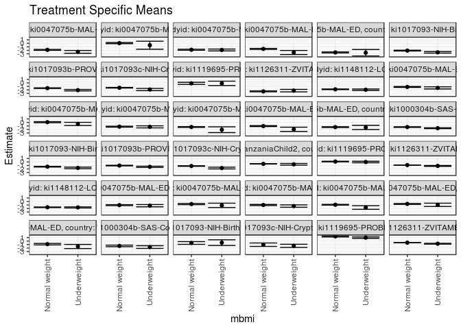

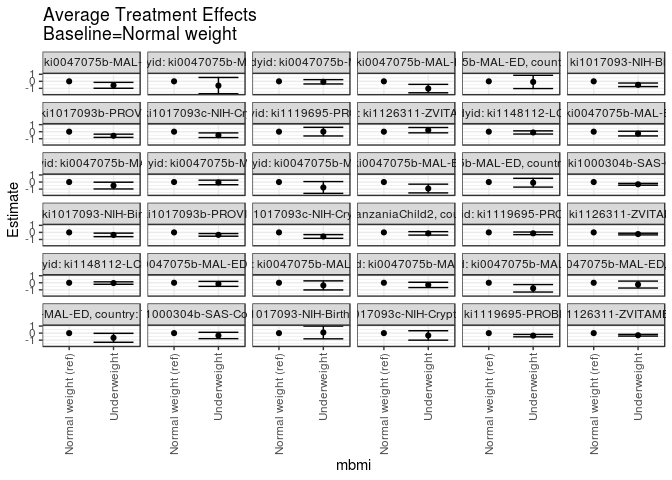

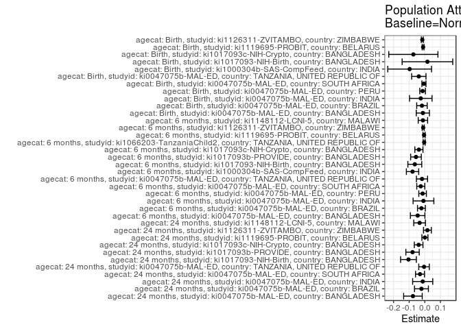

## Results Table

### Parameter: TSM

| agecat | studyid | country | intervention_level | baseline_level | estimate | ci_lower | ci_upper |
| --- | --- | --- | --- | --- | --- | --- | --- |
| Birth | ki0047075b-MAL-ED | BANGLADESH | Normal weight | NA | -1.0330002 | -1.1700099 | -0.8959905 |
| Birth | ki0047075b-MAL-ED | BANGLADESH | Underweight | NA | -1.1903856 | -1.5149899 | -0.8657813 |
| Birth | ki0047075b-MAL-ED | BRAZIL | Normal weight | NA | -0.7214286 | -0.8860242 | -0.5568330 |
| Birth | ki0047075b-MAL-ED | BRAZIL | Underweight | NA | -1.0955556 | -1.7166511 | -0.4744600 |
| Birth | ki0047075b-MAL-ED | INDIA | Normal weight | NA | -0.9942546 | -1.1527093 | -0.8357999 |
| Birth | ki0047075b-MAL-ED | INDIA | Underweight | NA | -1.2987230 | -1.6370157 | -0.9604303 |
| Birth | ki0047075b-MAL-ED | PERU | Normal weight | NA | -0.9244280 | -1.0379186 | -0.8109375 |
| Birth | ki0047075b-MAL-ED | PERU | Underweight | NA | -1.7080000 | -2.2260621 | -1.1899379 |
| Birth | ki0047075b-MAL-ED | SOUTH AFRICA | Normal weight | NA | -0.6865919 | -0.8189375 | -0.5542463 |
| Birth | ki0047075b-MAL-ED | SOUTH AFRICA | Underweight | NA | -0.9420000 | -1.4131562 | -0.4708438 |
| Birth | ki0047075b-MAL-ED | TANZANIA, UNITED REPUBLIC OF | Normal weight | NA | -0.8884211 | -1.1126576 | -0.6641845 |
| Birth | ki0047075b-MAL-ED | TANZANIA, UNITED REPUBLIC OF | Underweight | NA | -1.5514286 | -2.1432057 | -0.9596514 |
| Birth | ki1000304b-SAS-CompFeed | INDIA | Normal weight | NA | -1.3833881 | -1.6036486 | -1.1631275 |
| Birth | ki1000304b-SAS-CompFeed | INDIA | Underweight | NA | -1.7160384 | -2.1065522 | -1.3255245 |
| Birth | ki1017093-NIH-Birth | BANGLADESH | Normal weight | NA | -0.5460870 | -0.9370628 | -0.1551112 |
| Birth | ki1017093-NIH-Birth | BANGLADESH | Underweight | NA | -0.4520000 | -1.2667579 | 0.3627579 |
| Birth | ki1017093c-NIH-Crypto | BANGLADESH | Normal weight | NA | -1.0366667 | -1.5281526 | -0.5451807 |
| Birth | ki1017093c-NIH-Crypto | BANGLADESH | Underweight | NA | -1.3666667 | -1.8176632 | -0.9156702 |
| Birth | ki1119695-PROBIT | BELARUS | Normal weight | NA | 1.3372549 | 1.1774321 | 1.4970778 |
| Birth | ki1119695-PROBIT | BELARUS | Underweight | NA | 0.9821510 | 0.7763377 | 1.1879643 |
| Birth | ki1126311-ZVITAMBO | ZIMBABWE | Normal weight | NA | -0.4612212 | -0.4863552 | -0.4360872 |
| Birth | ki1126311-ZVITAMBO | ZIMBABWE | Underweight | NA | -0.7615624 | -0.8781851 | -0.6449396 |
| 6 months | ki0047075b-MAL-ED | BANGLADESH | Normal weight | NA | -1.1599332 | -1.2864717 | -1.0333947 |
| 6 months | ki0047075b-MAL-ED | BANGLADESH | Underweight | NA | -1.4303914 | -1.7370040 | -1.1237788 |
| 6 months | ki0047075b-MAL-ED | BRAZIL | Normal weight | NA | 0.0748995 | -0.0742030 | 0.2240020 |
| 6 months | ki0047075b-MAL-ED | BRAZIL | Underweight | NA | -0.4262963 | -0.8810079 | 0.0284153 |
| 6 months | ki0047075b-MAL-ED | INDIA | Normal weight | NA | -1.2062935 | -1.3403160 | -1.0722711 |
| 6 months | ki0047075b-MAL-ED | INDIA | Underweight | NA | -1.2634034 | -1.5543523 | -0.9724545 |
| 6 months | ki0047075b-MAL-ED | PERU | Normal weight | NA | -1.3131149 | -1.4218494 | -1.2043803 |
| 6 months | ki0047075b-MAL-ED | PERU | Underweight | NA | -2.0820000 | -2.9100519 | -1.2539481 |
| 6 months | ki0047075b-MAL-ED | SOUTH AFRICA | Normal weight | NA | -1.0469731 | -1.1780219 | -0.9159244 |
| 6 months | ki0047075b-MAL-ED | SOUTH AFRICA | Underweight | NA | -1.9657143 | -2.5717876 | -1.3596410 |
| 6 months | ki0047075b-MAL-ED | TANZANIA, UNITED REPUBLIC OF | Normal weight | NA | -1.3421466 | -1.4662385 | -1.2180547 |
| 6 months | ki0047075b-MAL-ED | TANZANIA, UNITED REPUBLIC OF | Underweight | NA | -1.4372829 | -2.0442777 | -0.8302880 |
| 6 months | ki1000304b-SAS-CompFeed | INDIA | Normal weight | NA | -1.3287323 | -1.4242629 | -1.2332017 |
| 6 months | ki1000304b-SAS-CompFeed | INDIA | Underweight | NA | -1.6494554 | -1.7687834 | -1.5301275 |
| 6 months | ki1017093-NIH-Birth | BANGLADESH | Normal weight | NA | -1.3433642 | -1.4389009 | -1.2478275 |
| 6 months | ki1017093-NIH-Birth | BANGLADESH | Underweight | NA | -1.6978898 | -1.9283770 | -1.4674027 |
| 6 months | ki1017093b-PROVIDE | BANGLADESH | Normal weight | NA | -1.0283416 | -1.1140136 | -0.9426697 |
| 6 months | ki1017093b-PROVIDE | BANGLADESH | Underweight | NA | -1.3777080 | -1.5473532 | -1.2080629 |
| 6 months | ki1017093c-NIH-Crypto | BANGLADESH | Normal weight | NA | -1.1608188 | -1.2347606 | -1.0868769 |
| 6 months | ki1017093c-NIH-Crypto | BANGLADESH | Underweight | NA | -1.7349522 | -1.9875495 | -1.4823549 |
| 6 months | ki1066203-TanzaniaChild2 | TANZANIA, UNITED REPUBLIC OF | Normal weight | NA | -0.5365276 | -0.5870572 | -0.4859980 |
| 6 months | ki1066203-TanzaniaChild2 | TANZANIA, UNITED REPUBLIC OF | Underweight | NA | -0.6718113 | -0.9131817 | -0.4304410 |
| 6 months | ki1119695-PROBIT | BELARUS | Normal weight | NA | 0.1202004 | 0.0276864 | 0.2127144 |
| 6 months | ki1119695-PROBIT | BELARUS | Underweight | NA | -0.0093074 | -0.2253648 | 0.2067499 |
| 6 months | ki1126311-ZVITAMBO | ZIMBABWE | Normal weight | NA | -0.8905878 | -0.9190837 | -0.8620919 |
| 6 months | ki1126311-ZVITAMBO | ZIMBABWE | Underweight | NA | -1.1251261 | -1.2439526 | -1.0062997 |
| 6 months | ki1148112-LCNI-5 | MALAWI | Normal weight | NA | -1.6456878 | -1.7239100 | -1.5674656 |
| 6 months | ki1148112-LCNI-5 | MALAWI | Underweight | NA | -1.6867135 | -1.8406644 | -1.5327626 |
| 24 months | ki0047075b-MAL-ED | BANGLADESH | Normal weight | NA | -1.8671806 | -1.9983091 | -1.7360521 |
| 24 months | ki0047075b-MAL-ED | BANGLADESH | Underweight | NA | -2.4330981 | -2.8288153 | -2.0373810 |
| 24 months | ki0047075b-MAL-ED | BRAZIL | Normal weight | NA | 0.0633642 | -0.1049962 | 0.2317246 |
| 24 months | ki0047075b-MAL-ED | BRAZIL | Underweight | NA | -0.5391667 | -1.6773310 | 0.5989977 |
| 24 months | ki0047075b-MAL-ED | INDIA | Normal weight | NA | -1.8304158 | -1.9728822 | -1.6879493 |
| 24 months | ki0047075b-MAL-ED | INDIA | Underweight | NA | -1.8992426 | -2.1701827 | -1.6283025 |
| 24 months | ki0047075b-MAL-ED | SOUTH AFRICA | Normal weight | NA | -1.5912775 | -1.7294629 | -1.4530921 |
| 24 months | ki0047075b-MAL-ED | SOUTH AFRICA | Underweight | NA | -2.6192857 | -3.1998173 | -2.0387542 |
| 24 months | ki0047075b-MAL-ED | TANZANIA, UNITED REPUBLIC OF | Normal weight | NA | -2.6009757 | -2.7386910 | -2.4632604 |
| 24 months | ki0047075b-MAL-ED | TANZANIA, UNITED REPUBLIC OF | Underweight | NA | -2.6872199 | -3.6184534 | -1.7559863 |
| 24 months | ki1017093-NIH-Birth | BANGLADESH | Normal weight | NA | -2.0762334 | -2.1897765 | -1.9626902 |
| 24 months | ki1017093-NIH-Birth | BANGLADESH | Underweight | NA | -2.5724238 | -2.7969811 | -2.3478664 |
| 24 months | ki1017093b-PROVIDE | BANGLADESH | Normal weight | NA | -1.5054904 | -1.5969268 | -1.4140540 |
| 24 months | ki1017093b-PROVIDE | BANGLADESH | Underweight | NA | -2.0851294 | -2.2944232 | -1.8758355 |
| 24 months | ki1017093c-NIH-Crypto | BANGLADESH | Normal weight | NA | -1.3900208 | -1.4762173 | -1.3038243 |
| 24 months | ki1017093c-NIH-Crypto | BANGLADESH | Underweight | NA | -1.8935088 | -2.2130055 | -1.5740120 |
| 24 months | ki1119695-PROBIT | BELARUS | Normal weight | NA | -0.1328929 | -0.4362385 | 0.1704527 |
| 24 months | ki1119695-PROBIT | BELARUS | Underweight | NA | -0.1287721 | -0.7484555 | 0.4909114 |
| 24 months | ki1126311-ZVITAMBO | ZIMBABWE | Normal weight | NA | -2.4302086 | -2.5598507 | -2.3005665 |
| 24 months | ki1126311-ZVITAMBO | ZIMBABWE | Underweight | NA | -2.2142496 | -2.5665288 | -1.8619704 |
| 24 months | ki1148112-LCNI-5 | MALAWI | Normal weight | NA | -1.8410323 | -1.9305849 | -1.7514798 |
| 24 months | ki1148112-LCNI-5 | MALAWI | Underweight | NA | -1.9516562 | -2.1576510 | -1.7456613 |

### Parameter: E(Y)

| agecat | studyid | country | intervention_level | baseline_level | estimate | ci_lower | ci_upper |
| --- | --- | --- | --- | --- | --- | --- | --- |
| Birth | ki0047075b-MAL-ED | BANGLADESH | NA | NA | -1.0455285 | -1.1715695 | -0.9194875 |
| Birth | ki0047075b-MAL-ED | BRAZIL | NA | NA | -0.7397283 | -0.8996215 | -0.5798350 |
| Birth | ki0047075b-MAL-ED | INDIA | NA | NA | -1.0200505 | -1.1624932 | -0.8776078 |
| Birth | ki0047075b-MAL-ED | PERU | NA | NA | -0.9386232 | -1.0507144 | -0.8265319 |
| Birth | ki0047075b-MAL-ED | SOUTH AFRICA | NA | NA | -0.6921930 | -0.8218578 | -0.5625282 |
| Birth | ki0047075b-MAL-ED | TANZANIA, UNITED REPUBLIC OF | NA | NA | -0.9267769 | -1.1425813 | -0.7109724 |
| Birth | ki1000304b-SAS-CompFeed | INDIA | NA | NA | -1.4803846 | -1.6742160 | -1.2865532 |
| Birth | ki1017093-NIH-Birth | BANGLADESH | NA | NA | -0.5292857 | -0.8821252 | -0.1764462 |
| Birth | ki1017093c-NIH-Crypto | BANGLADESH | NA | NA | -1.1100000 | -1.5086894 | -0.7113106 |
| Birth | ki1119695-PROBIT | BELARUS | NA | NA | 1.3263412 | 1.1672322 | 1.4854501 |
| Birth | ki1126311-ZVITAMBO | ZIMBABWE | NA | NA | -0.4772566 | -0.5017796 | -0.4527336 |
| 6 months | ki0047075b-MAL-ED | BANGLADESH | NA | NA | -1.2056777 | -1.3231497 | -1.0882058 |
| 6 months | ki0047075b-MAL-ED | BRAZIL | NA | NA | 0.0532131 | -0.0914567 | 0.1978830 |
| 6 months | ki0047075b-MAL-ED | INDIA | NA | NA | -1.2148369 | -1.3332371 | -1.0964367 |
| 6 months | ki0047075b-MAL-ED | PERU | NA | NA | -1.3272488 | -1.4359649 | -1.2185326 |
| 6 months | ki0047075b-MAL-ED | SOUTH AFRICA | NA | NA | -1.0728012 | -1.2026830 | -0.9429194 |
| 6 months | ki0047075b-MAL-ED | TANZANIA, UNITED REPUBLIC OF | NA | NA | -1.3601215 | -1.4821830 | -1.2380600 |
| 6 months | ki1000304b-SAS-CompFeed | INDIA | NA | NA | -1.4072209 | -1.4983514 | -1.3160903 |
| 6 months | ki1017093-NIH-Birth | BANGLADESH | NA | NA | -1.4073821 | -1.4960598 | -1.3187043 |
| 6 months | ki1017093b-PROVIDE | BANGLADESH | NA | NA | -1.0848568 | -1.1613109 | -1.0084028 |
| 6 months | ki1017093c-NIH-Crypto | BANGLADESH | NA | NA | -1.1986783 | -1.2700937 | -1.1272630 |
| 6 months | ki1066203-TanzaniaChild2 | TANZANIA, UNITED REPUBLIC OF | NA | NA | -0.5405711 | -0.5899965 | -0.4911457 |
| 6 months | ki1119695-PROBIT | BELARUS | NA | NA | 0.1153731 | 0.0222128 | 0.2085334 |
| 6 months | ki1126311-ZVITAMBO | ZIMBABWE | NA | NA | -0.9008757 | -0.9285733 | -0.8731780 |
| 6 months | ki1148112-LCNI-5 | MALAWI | NA | NA | -1.6577751 | -1.7275296 | -1.5880207 |
| 24 months | ki0047075b-MAL-ED | BANGLADESH | NA | NA | -1.9431132 | -2.0691678 | -1.8170586 |
| 24 months | ki0047075b-MAL-ED | BRAZIL | NA | NA | 0.0418452 | -0.1263708 | 0.2100613 |
| 24 months | ki0047075b-MAL-ED | INDIA | NA | NA | -1.8439159 | -1.9704751 | -1.7173568 |
| 24 months | ki0047075b-MAL-ED | SOUTH AFRICA | NA | NA | -1.6220299 | -1.7590593 | -1.4850005 |
| 24 months | ki0047075b-MAL-ED | TANZANIA, UNITED REPUBLIC OF | NA | NA | -2.6058879 | -2.7403043 | -2.4714714 |
| 24 months | ki1017093-NIH-Birth | BANGLADESH | NA | NA | -2.1807945 | -2.2835902 | -2.0779987 |
| 24 months | ki1017093b-PROVIDE | BANGLADESH | NA | NA | -1.5839236 | -1.6672059 | -1.5006413 |
| 24 months | ki1017093c-NIH-Crypto | BANGLADESH | NA | NA | -1.4295331 | -1.5127726 | -1.3462935 |
| 24 months | ki1119695-PROBIT | BELARUS | NA | NA | -0.1322181 | -0.4300523 | 0.1656161 |
| 24 months | ki1126311-ZVITAMBO | ZIMBABWE | NA | NA | -2.4135279 | -2.5366872 | -2.2903685 |
| 24 months | ki1148112-LCNI-5 | MALAWI | NA | NA | -1.8744367 | -1.9556750 | -1.7931984 |

### Parameter: ATE

| agecat | studyid | country | intervention_level | baseline_level | estimate | ci_lower | ci_upper |
| --- | --- | --- | --- | --- | --- | --- | --- |
| Birth | ki0047075b-MAL-ED | BANGLADESH | Normal weight | Normal weight | 0.0000000 | 0.0000000 | 0.0000000 |
| Birth | ki0047075b-MAL-ED | BANGLADESH | Underweight | Normal weight | -0.1573854 | -0.5116844 | 0.1969136 |
| Birth | ki0047075b-MAL-ED | BRAZIL | Normal weight | Normal weight | 0.0000000 | 0.0000000 | 0.0000000 |
| Birth | ki0047075b-MAL-ED | BRAZIL | Underweight | Normal weight | -0.3741270 | -1.0166621 | 0.2684082 |
| Birth | ki0047075b-MAL-ED | INDIA | Normal weight | Normal weight | 0.0000000 | 0.0000000 | 0.0000000 |
| Birth | ki0047075b-MAL-ED | INDIA | Underweight | Normal weight | -0.3044684 | -0.6785472 | 0.0696105 |
| Birth | ki0047075b-MAL-ED | PERU | Normal weight | Normal weight | 0.0000000 | 0.0000000 | 0.0000000 |
| Birth | ki0047075b-MAL-ED | PERU | Underweight | Normal weight | -0.7835720 | -1.3139194 | -0.2532245 |
| Birth | ki0047075b-MAL-ED | SOUTH AFRICA | Normal weight | Normal weight | 0.0000000 | 0.0000000 | 0.0000000 |
| Birth | ki0047075b-MAL-ED | SOUTH AFRICA | Underweight | Normal weight | -0.2554081 | -0.7447990 | 0.2339829 |
| Birth | ki0047075b-MAL-ED | TANZANIA, UNITED REPUBLIC OF | Normal weight | Normal weight | 0.0000000 | 0.0000000 | 0.0000000 |
| Birth | ki0047075b-MAL-ED | TANZANIA, UNITED REPUBLIC OF | Underweight | Normal weight | -0.6630075 | -1.2958441 | -0.0301709 |
| Birth | ki1000304b-SAS-CompFeed | INDIA | Normal weight | Normal weight | 0.0000000 | 0.0000000 | 0.0000000 |
| Birth | ki1000304b-SAS-CompFeed | INDIA | Underweight | Normal weight | -0.3326503 | -0.7799828 | 0.1146822 |
| Birth | ki1017093-NIH-Birth | BANGLADESH | Normal weight | Normal weight | 0.0000000 | 0.0000000 | 0.0000000 |
| Birth | ki1017093-NIH-Birth | BANGLADESH | Underweight | Normal weight | 0.0940870 | -0.8096235 | 0.9977974 |
| Birth | ki1017093c-NIH-Crypto | BANGLADESH | Normal weight | Normal weight | 0.0000000 | 0.0000000 | 0.0000000 |
| Birth | ki1017093c-NIH-Crypto | BANGLADESH | Underweight | Normal weight | -0.3300000 | -0.9970504 | 0.3370504 |
| Birth | ki1119695-PROBIT | BELARUS | Normal weight | Normal weight | 0.0000000 | 0.0000000 | 0.0000000 |
| Birth | ki1119695-PROBIT | BELARUS | Underweight | Normal weight | -0.3551039 | -0.5232466 | -0.1869613 |
| Birth | ki1126311-ZVITAMBO | ZIMBABWE | Normal weight | Normal weight | 0.0000000 | 0.0000000 | 0.0000000 |
| Birth | ki1126311-ZVITAMBO | ZIMBABWE | Underweight | Normal weight | -0.3003412 | -0.4196637 | -0.1810187 |
| 6 months | ki0047075b-MAL-ED | BANGLADESH | Normal weight | Normal weight | 0.0000000 | 0.0000000 | 0.0000000 |
| 6 months | ki0047075b-MAL-ED | BANGLADESH | Underweight | Normal weight | -0.2704582 | -0.6032043 | 0.0622879 |
| 6 months | ki0047075b-MAL-ED | BRAZIL | Normal weight | Normal weight | 0.0000000 | 0.0000000 | 0.0000000 |
| 6 months | ki0047075b-MAL-ED | BRAZIL | Underweight | Normal weight | -0.5011958 | -0.9797291 | -0.0226625 |
| 6 months | ki0047075b-MAL-ED | INDIA | Normal weight | Normal weight | 0.0000000 | 0.0000000 | 0.0000000 |
| 6 months | ki0047075b-MAL-ED | INDIA | Underweight | Normal weight | -0.0571099 | -0.3812557 | 0.2670359 |
| 6 months | ki0047075b-MAL-ED | PERU | Normal weight | Normal weight | 0.0000000 | 0.0000000 | 0.0000000 |
| 6 months | ki0047075b-MAL-ED | PERU | Underweight | Normal weight | -0.7688851 | -1.6040457 | 0.0662754 |
| 6 months | ki0047075b-MAL-ED | SOUTH AFRICA | Normal weight | Normal weight | 0.0000000 | 0.0000000 | 0.0000000 |
| 6 months | ki0047075b-MAL-ED | SOUTH AFRICA | Underweight | Normal weight | -0.9187411 | -1.5388207 | -0.2986616 |
| 6 months | ki0047075b-MAL-ED | TANZANIA, UNITED REPUBLIC OF | Normal weight | Normal weight | 0.0000000 | 0.0000000 | 0.0000000 |
| 6 months | ki0047075b-MAL-ED | TANZANIA, UNITED REPUBLIC OF | Underweight | Normal weight | -0.0951363 | -0.7147160 | 0.5244435 |
| 6 months | ki1000304b-SAS-CompFeed | INDIA | Normal weight | Normal weight | 0.0000000 | 0.0000000 | 0.0000000 |
| 6 months | ki1000304b-SAS-CompFeed | INDIA | Underweight | Normal weight | -0.3207231 | -0.4481507 | -0.1932956 |
| 6 months | ki1017093-NIH-Birth | BANGLADESH | Normal weight | Normal weight | 0.0000000 | 0.0000000 | 0.0000000 |
| 6 months | ki1017093-NIH-Birth | BANGLADESH | Underweight | Normal weight | -0.3545256 | -0.6043748 | -0.1046764 |
| 6 months | ki1017093b-PROVIDE | BANGLADESH | Normal weight | Normal weight | 0.0000000 | 0.0000000 | 0.0000000 |
| 6 months | ki1017093b-PROVIDE | BANGLADESH | Underweight | Normal weight | -0.3493664 | -0.5391242 | -0.1596085 |
| 6 months | ki1017093c-NIH-Crypto | BANGLADESH | Normal weight | Normal weight | 0.0000000 | 0.0000000 | 0.0000000 |
| 6 months | ki1017093c-NIH-Crypto | BANGLADESH | Underweight | Normal weight | -0.5741335 | -0.8378672 | -0.3103997 |
| 6 months | ki1066203-TanzaniaChild2 | TANZANIA, UNITED REPUBLIC OF | Normal weight | Normal weight | 0.0000000 | 0.0000000 | 0.0000000 |
| 6 months | ki1066203-TanzaniaChild2 | TANZANIA, UNITED REPUBLIC OF | Underweight | Normal weight | -0.1352837 | -0.3819274 | 0.1113599 |
| 6 months | ki1119695-PROBIT | BELARUS | Normal weight | Normal weight | 0.0000000 | 0.0000000 | 0.0000000 |
| 6 months | ki1119695-PROBIT | BELARUS | Underweight | Normal weight | -0.1295078 | -0.3135498 | 0.0545341 |
| 6 months | ki1126311-ZVITAMBO | ZIMBABWE | Normal weight | Normal weight | 0.0000000 | 0.0000000 | 0.0000000 |
| 6 months | ki1126311-ZVITAMBO | ZIMBABWE | Underweight | Normal weight | -0.2345383 | -0.3567294 | -0.1123473 |
| 6 months | ki1148112-LCNI-5 | MALAWI | Normal weight | Normal weight | 0.0000000 | 0.0000000 | 0.0000000 |
| 6 months | ki1148112-LCNI-5 | MALAWI | Underweight | Normal weight | -0.0410257 | -0.2137613 | 0.1317099 |
| 24 months | ki0047075b-MAL-ED | BANGLADESH | Normal weight | Normal weight | 0.0000000 | 0.0000000 | 0.0000000 |
| 24 months | ki0047075b-MAL-ED | BANGLADESH | Underweight | Normal weight | -0.5659176 | -0.9842862 | -0.1475489 |
| 24 months | ki0047075b-MAL-ED | BRAZIL | Normal weight | Normal weight | 0.0000000 | 0.0000000 | 0.0000000 |
| 24 months | ki0047075b-MAL-ED | BRAZIL | Underweight | Normal weight | -0.6025309 | -1.7530800 | 0.5480183 |
| 24 months | ki0047075b-MAL-ED | INDIA | Normal weight | Normal weight | 0.0000000 | 0.0000000 | 0.0000000 |
| 24 months | ki0047075b-MAL-ED | INDIA | Underweight | Normal weight | -0.0688268 | -0.3756575 | 0.2380038 |
| 24 months | ki0047075b-MAL-ED | SOUTH AFRICA | Normal weight | Normal weight | 0.0000000 | 0.0000000 | 0.0000000 |
| 24 months | ki0047075b-MAL-ED | SOUTH AFRICA | Underweight | Normal weight | -1.0280082 | -1.6247594 | -0.4312569 |
| 24 months | ki0047075b-MAL-ED | TANZANIA, UNITED REPUBLIC OF | Normal weight | Normal weight | 0.0000000 | 0.0000000 | 0.0000000 |
| 24 months | ki0047075b-MAL-ED | TANZANIA, UNITED REPUBLIC OF | Underweight | Normal weight | -0.0862442 | -1.0278954 | 0.8554071 |
| 24 months | ki1017093-NIH-Birth | BANGLADESH | Normal weight | Normal weight | 0.0000000 | 0.0000000 | 0.0000000 |
| 24 months | ki1017093-NIH-Birth | BANGLADESH | Underweight | Normal weight | -0.4961904 | -0.7484799 | -0.2439009 |
| 24 months | ki1017093b-PROVIDE | BANGLADESH | Normal weight | Normal weight | 0.0000000 | 0.0000000 | 0.0000000 |
| 24 months | ki1017093b-PROVIDE | BANGLADESH | Underweight | Normal weight | -0.5796390 | -0.8083617 | -0.3509163 |
| 24 months | ki1017093c-NIH-Crypto | BANGLADESH | Normal weight | Normal weight | 0.0000000 | 0.0000000 | 0.0000000 |
| 24 months | ki1017093c-NIH-Crypto | BANGLADESH | Underweight | Normal weight | -0.5034880 | -0.8345964 | -0.1723795 |
| 24 months | ki1119695-PROBIT | BELARUS | Normal weight | Normal weight | 0.0000000 | 0.0000000 | 0.0000000 |
| 24 months | ki1119695-PROBIT | BELARUS | Underweight | Normal weight | 0.0041208 | -0.6085598 | 0.6168014 |
| 24 months | ki1126311-ZVITAMBO | ZIMBABWE | Normal weight | Normal weight | 0.0000000 | 0.0000000 | 0.0000000 |
| 24 months | ki1126311-ZVITAMBO | ZIMBABWE | Underweight | Normal weight | 0.2159590 | -0.1603946 | 0.5923125 |
| 24 months | ki1148112-LCNI-5 | MALAWI | Normal weight | Normal weight | 0.0000000 | 0.0000000 | 0.0000000 |
| 24 months | ki1148112-LCNI-5 | MALAWI | Underweight | Normal weight | -0.1106238 | -0.3360554 | 0.1148078 |

### Parameter: PAR

| agecat | studyid | country | intervention_level | baseline_level | estimate | ci_lower | ci_upper |
| --- | --- | --- | --- | --- | --- | --- | --- |
| Birth | ki0047075b-MAL-ED | BANGLADESH | Normal weight | NA | -0.0125282 | -0.0546780 | 0.0296215 |
| Birth | ki0047075b-MAL-ED | BRAZIL | Normal weight | NA | -0.0182997 | -0.0518322 | 0.0152328 |
| Birth | ki0047075b-MAL-ED | INDIA | Normal weight | NA | -0.0257959 | -0.0978994 | 0.0463076 |
| Birth | ki0047075b-MAL-ED | PERU | Normal weight | NA | -0.0141951 | -0.0323157 | 0.0039254 |
| Birth | ki0047075b-MAL-ED | SOUTH AFRICA | Normal weight | NA | -0.0056011 | -0.0187680 | 0.0075659 |
| Birth | ki0047075b-MAL-ED | TANZANIA, UNITED REPUBLIC OF | Normal weight | NA | -0.0383558 | -0.0842611 | 0.0075495 |
| Birth | ki1000304b-SAS-CompFeed | INDIA | Normal weight | NA | -0.0969966 | -0.2369592 | 0.0429660 |
| Birth | ki1017093-NIH-Birth | BANGLADESH | Normal weight | NA | 0.0168012 | -0.1451470 | 0.1787495 |
| Birth | ki1017093c-NIH-Crypto | BANGLADESH | Normal weight | NA | -0.0733333 | -0.2306677 | 0.0840010 |
| Birth | ki1119695-PROBIT | BELARUS | Normal weight | NA | -0.0109138 | -0.0165801 | -0.0052474 |
| Birth | ki1126311-ZVITAMBO | ZIMBABWE | Normal weight | NA | -0.0160354 | -0.0221617 | -0.0099092 |
| 6 months | ki0047075b-MAL-ED | BANGLADESH | Normal weight | NA | -0.0457445 | -0.0920460 | 0.0005570 |
| 6 months | ki0047075b-MAL-ED | BRAZIL | Normal weight | NA | -0.0216864 | -0.0466204 | 0.0032477 |
| 6 months | ki0047075b-MAL-ED | INDIA | Normal weight | NA | -0.0085433 | -0.0749689 | 0.0578822 |
| 6 months | ki0047075b-MAL-ED | PERU | Normal weight | NA | -0.0141339 | -0.0383650 | 0.0100972 |
| 6 months | ki0047075b-MAL-ED | SOUTH AFRICA | Normal weight | NA | -0.0258281 | -0.0515400 | -0.0001162 |
| 6 months | ki0047075b-MAL-ED | TANZANIA, UNITED REPUBLIC OF | Normal weight | NA | -0.0179749 | -0.0536293 | 0.0176796 |
| 6 months | ki1000304b-SAS-CompFeed | INDIA | Normal weight | NA | -0.0784886 | -0.1179838 | -0.0389933 |
| 6 months | ki1017093-NIH-Birth | BANGLADESH | Normal weight | NA | -0.0640178 | -0.1084592 | -0.0195765 |
| 6 months | ki1017093b-PROVIDE | BANGLADESH | Normal weight | NA | -0.0565152 | -0.0905523 | -0.0224781 |
| 6 months | ki1017093c-NIH-Crypto | BANGLADESH | Normal weight | NA | -0.0378596 | -0.0638330 | -0.0118861 |
| 6 months | ki1066203-TanzaniaChild2 | TANZANIA, UNITED REPUBLIC OF | Normal weight | NA | -0.0040435 | -0.0105280 | 0.0024410 |
| 6 months | ki1119695-PROBIT | BELARUS | Normal weight | NA | -0.0048274 | -0.0116794 | 0.0020247 |
| 6 months | ki1126311-ZVITAMBO | ZIMBABWE | Normal weight | NA | -0.0102878 | -0.0166254 | -0.0039503 |
| 6 months | ki1148112-LCNI-5 | MALAWI | Normal weight | NA | -0.0120873 | -0.0421931 | 0.0180185 |
| 24 months | ki0047075b-MAL-ED | BANGLADESH | Normal weight | NA | -0.0759326 | -0.1354491 | -0.0164161 |
| 24 months | ki0047075b-MAL-ED | BRAZIL | Normal weight | NA | -0.0215190 | -0.0659720 | 0.0229341 |
| 24 months | ki0047075b-MAL-ED | INDIA | Normal weight | NA | -0.0135002 | -0.0778662 | 0.0508659 |
| 24 months | ki0047075b-MAL-ED | SOUTH AFRICA | Normal weight | NA | -0.0307524 | -0.0594630 | -0.0020418 |
| 24 months | ki0047075b-MAL-ED | TANZANIA, UNITED REPUBLIC OF | Normal weight | NA | -0.0049122 | -0.0385622 | 0.0287379 |
| 24 months | ki1017093-NIH-Birth | BANGLADESH | Normal weight | NA | -0.1045611 | -0.1549995 | -0.0541227 |
| 24 months | ki1017093b-PROVIDE | BANGLADESH | Normal weight | NA | -0.0784332 | -0.1212151 | -0.0356514 |
| 24 months | ki1017093c-NIH-Crypto | BANGLADESH | Normal weight | NA | -0.0395123 | -0.0671266 | -0.0118979 |
| 24 months | ki1119695-PROBIT | BELARUS | Normal weight | NA | 0.0006748 | -0.0186401 | 0.0199898 |
| 24 months | ki1126311-ZVITAMBO | ZIMBABWE | Normal weight | NA | 0.0166807 | -0.0082814 | 0.0416429 |
| 24 months | ki1148112-LCNI-5 | MALAWI | Normal weight | NA | -0.0334044 | -0.0707076 | 0.0038988 |